# Predicción de precios de las casas en Boston

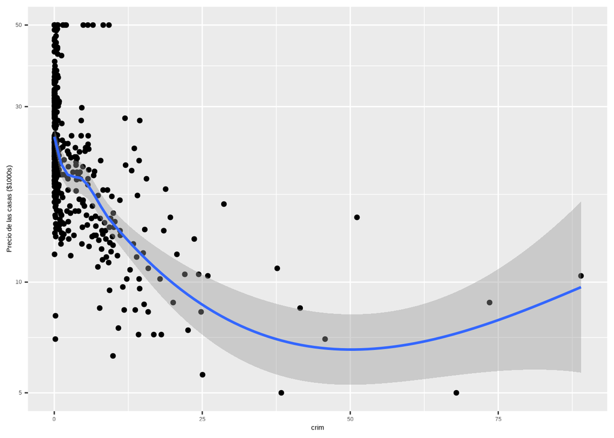

Figura 9b. Gráficos de dispersión (en escala logaritmica)

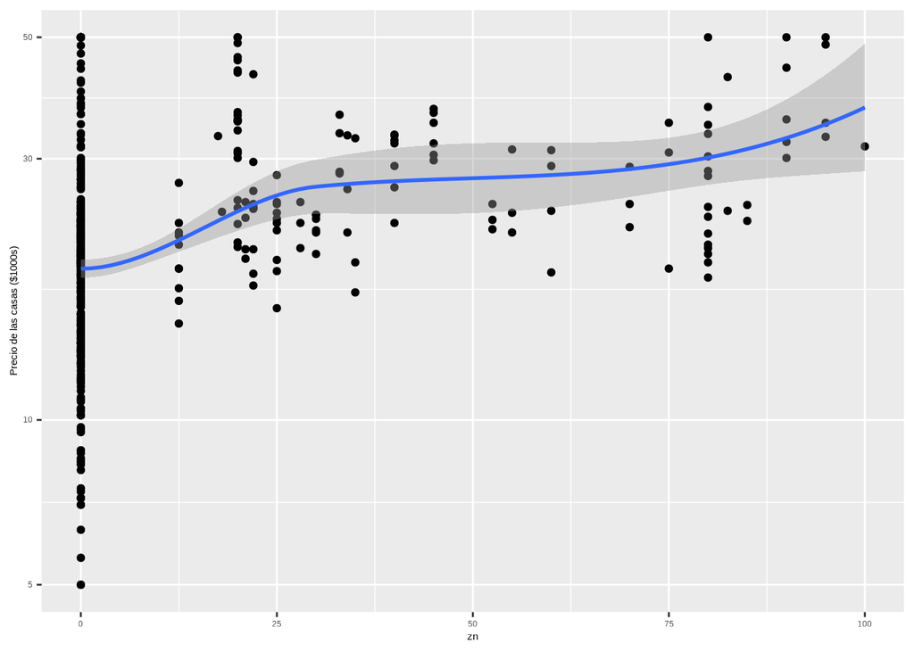

Figura 9b. Gráficos de dispersión (en escala logaritmica)

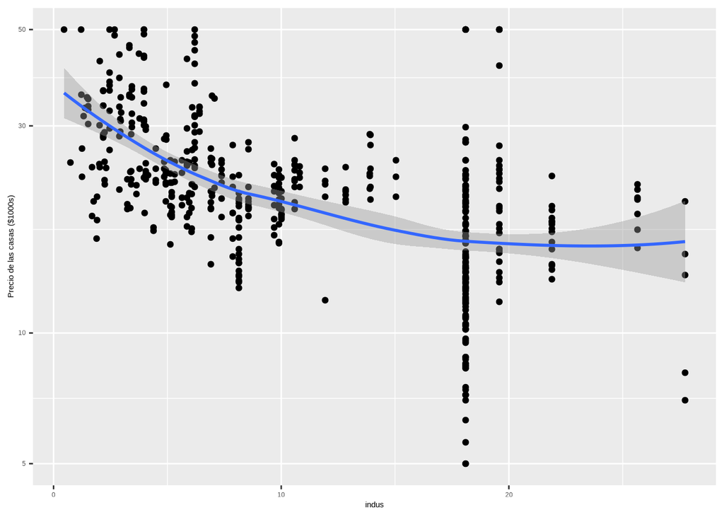

Figura 9b. Gráficos de dispersión (en escala logaritmica)

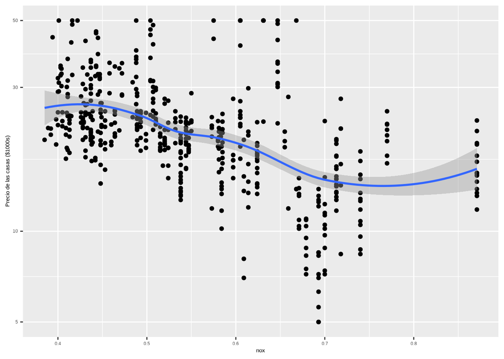

Figura 9b. Gráficos de dispersión (en escala logaritmica)

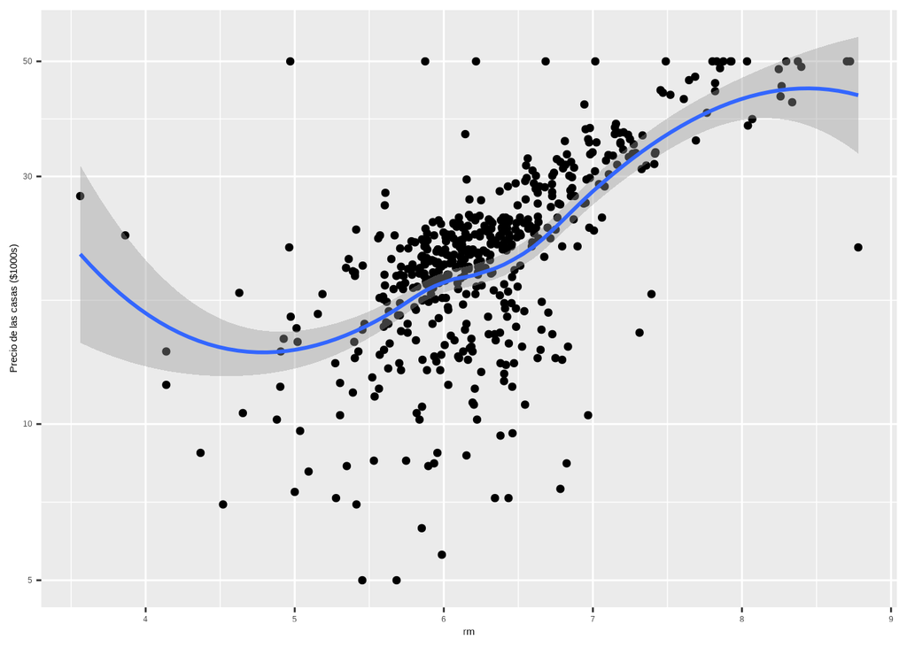

Figura 9b. Gráficos de dispersión (en escala logaritmica)

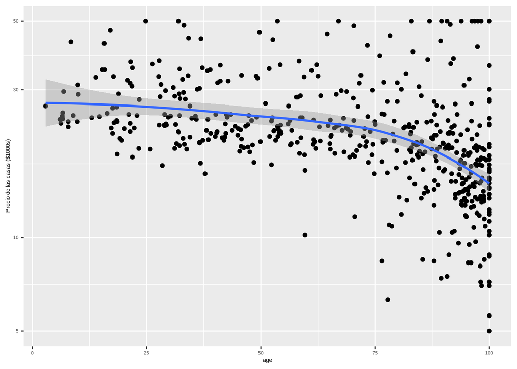

Figura 9b. Gráficos de dispersión (en escala logaritmica)

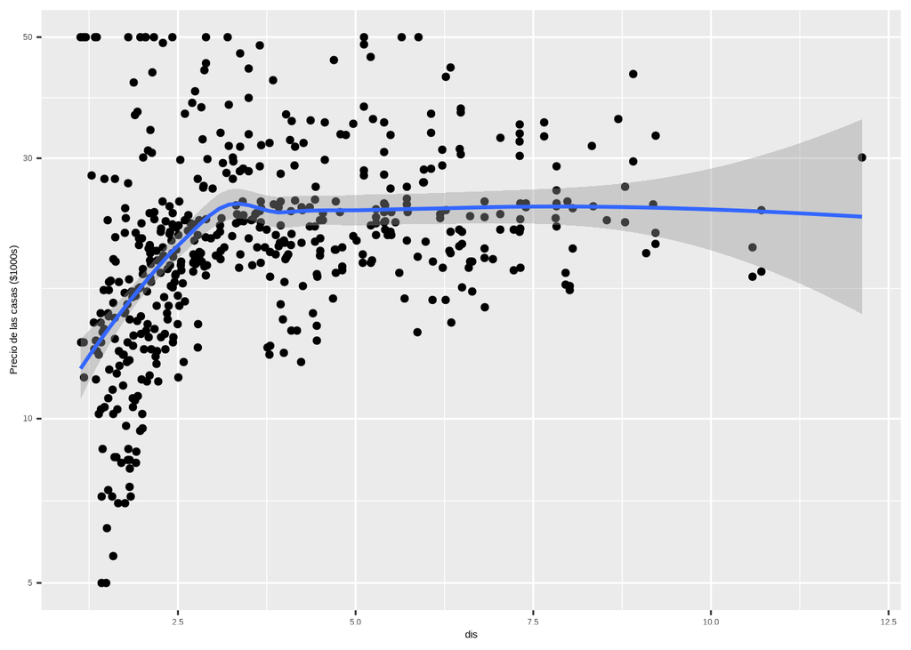

Figura 9b. Gráficos de dispersión (en escala logaritmica)

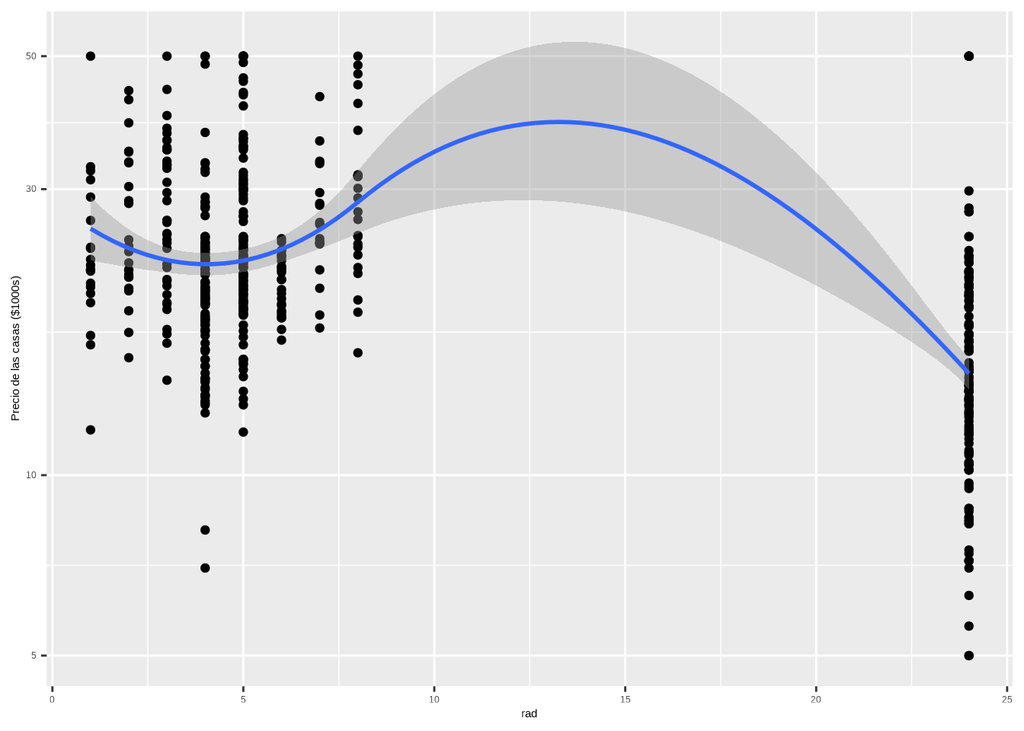

Figura 9b. Gráficos de dispersión (en escala logaritmica)

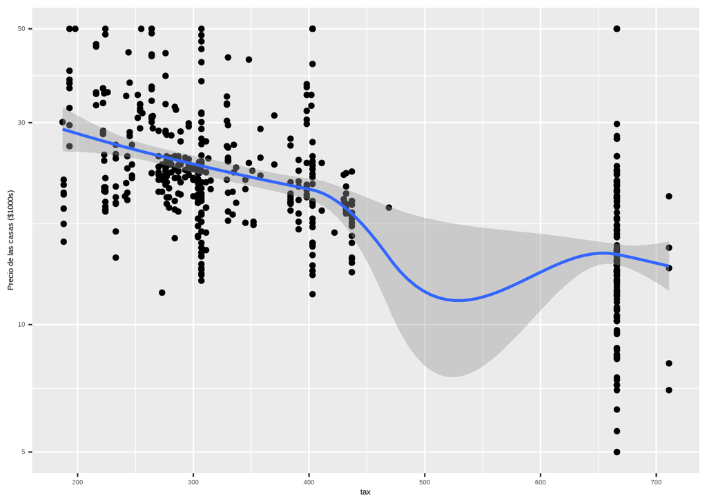

Figura 9b. Gráficos de dispersión (en escala logaritmica)

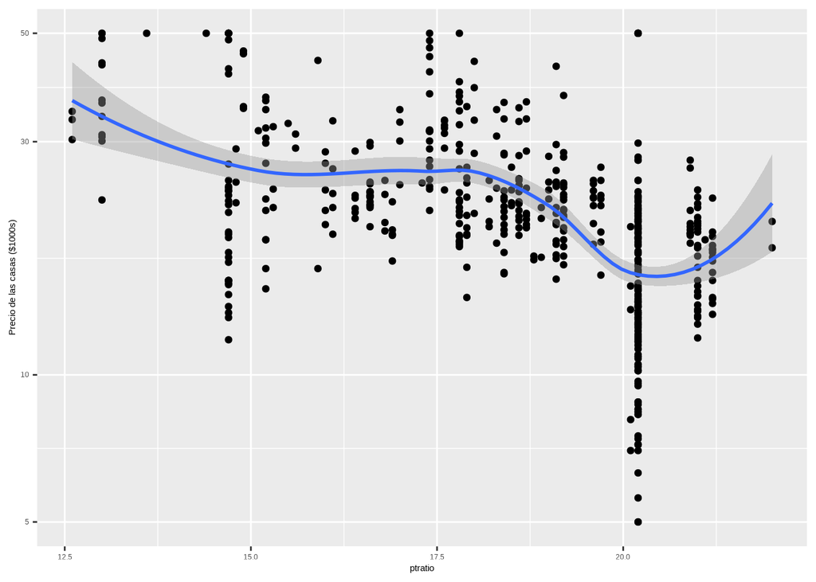

Figura 9b. Gráficos de dispersión (en escala logaritmica)

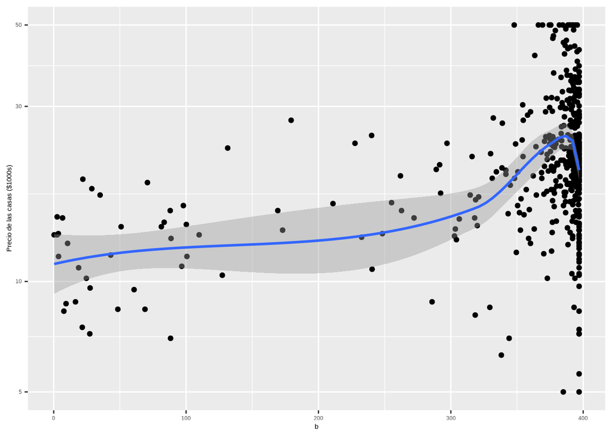

Figura 9b. Gráficos de dispersión (en escala logaritmica)

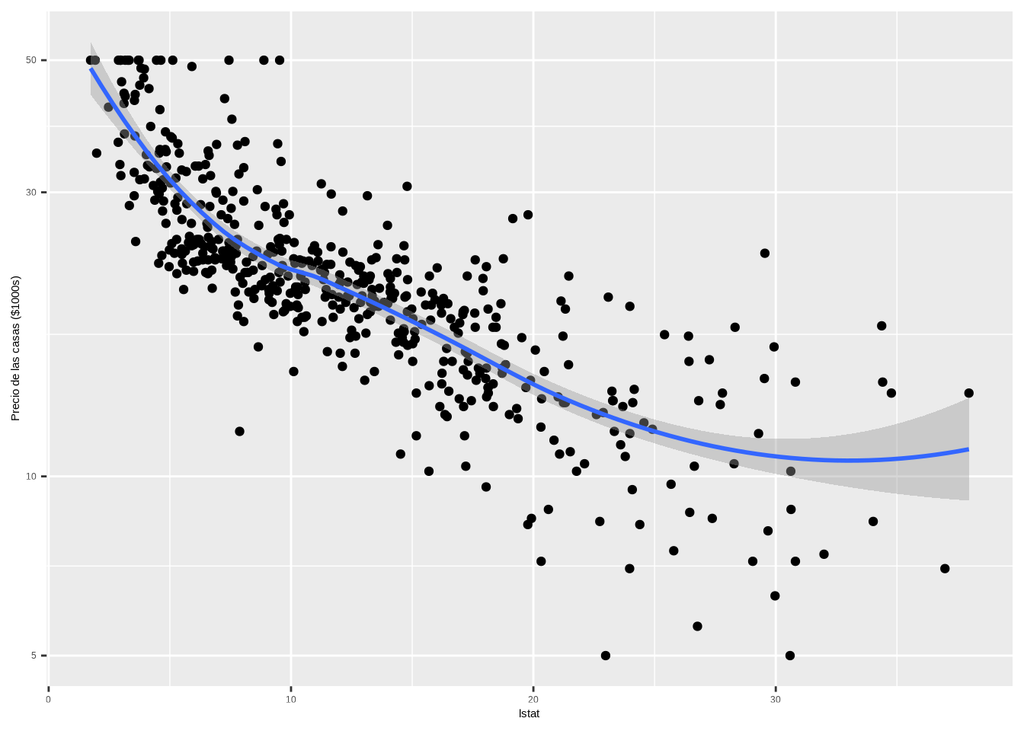

Figura 9b. Gráficos de dispersión (en escala logaritmica)

```r
vars <- c("crim", "zn", "indus", "nox", "rm", "age", "dis", "rad", "tax", "ptratio", "b", "lstat")

for (v in vars) {
  migraf <-  Boston |>
              ggplot(aes_string(x = v, y = "medv")) +
              geom_point() +  geom_smooth() +
              labs(x = v, y = "Precio de las casas ($1000s)")  +
              scale_y_log10()
  print(migraf)
}
```

En primer lugar, no se aprecian grandes diferencias entre el modelo con el precio sin transformar o en logaritmos. En segundo lugar, sí se aprecia cierta no linealidad en la relación con las variables de edad, número de habitaciones y porcentaje de población desfavorecida. En el resto de relaciones, no están tan claras por la acumulación de valores.

También se podrían haber probado si este análisis de covariación es distinto según distintos valores de una varible categórica. Por ejemplo, visualizar la relación entre precio y tasa de pobreza cuando la zona está cerca del rio y cuando no está cerca.

Podemos probar discretizando algunas de las variables comentadas anteriormente. Por ejemplo, hacemos dos grupos de criminalidad; los umbrales para discretizar no tienen una justificación muy formal: se basan en lo que aproximadamente hemos visto.

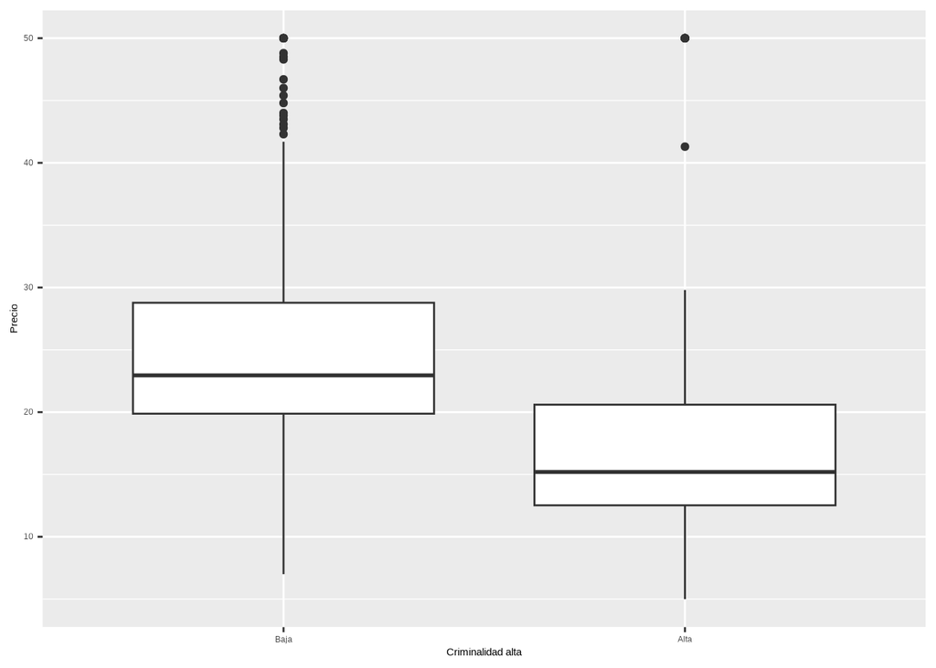

Figura 10. Gráficos Criminalidad Discreta

```r
  Boston |>
      mutate(crim.alta = cut(crim, breaks = c(0,1,Inf),
                             include.lowest = TRUE,
                             labels = c("Baja","Alta") ) ) |>
      ggplot(aes(y = medv, x = crim.alta)) +  geom_boxplot() + ylab("Densidad") + xlab("Criminalidad alta") + ylab("Precio")
```

```r
Boston_temp <-
  Boston |>
    mutate(crim.alta = cut(crim, breaks = c(0,1,Inf),
                         include.lowest = TRUE,
                         labels = c("Baja","Alta")))

lm(data = Boston_temp, medv ~ crim.alta) |>
  tidy() |>
  kbl(digits = 2, caption = "Tabla 4. Precio según criminalidad") |>
  kable_paper("hover")
```

Tabla 4. Precio según criminalidad

| term | estimate | std.error | statistic | p.value |
| --- | --- | --- | --- | --- |
| (Intercept) | 25.11 | 0.47 | 53.91 | 0 |
| crim.altaAlta | -7.50 | 0.79 | -9.44 | 0 |

```r
rm(Boston_temp)
```

Nota: existe una forma alternativa más limpia (para no tener que borrar un objeto temporal). El símbolo `_` se refiere al “data frame” que viene de la tubería. En general, NO es necesario (sobre todo con funciones de `tidyverse`), pero con `lm()` sí.

Tanto el gráfico como la regresión apuntan a un efecto significativo de la criminalidad sobre los precios. En principio deberíamos probar con otros puntos de corte para discretizar, pero por simplicidad utilizaremos este obtenido a partir del análisis exploratorio.

Podemos proceder de manera similar con otras variables. Nuevamente, tanto el número de grupos como los valores de corte no se derivan de forma super rigurosa, sino en base al análisis exploratorio. Debería probarse con otras variantes.

```r
Boston |>
  mutate(dis.alta = cut(dis, breaks = c(0,3,Inf),
                        include.lowest = TRUE,
                        labels = c("Baja","Alta") ) ) |>
  lm(data = _, medv ~ dis.alta) |> tidy() |>
  kbl(digits = 2, caption = "Tabla 5. Precio según distancia") |> kable_paper("hover")
```

Tabla 5. Precio según distancia

| term | estimate | std.error | statistic | p.value |
| --- | --- | --- | --- | --- |
| (Intercept) | 19.73 | 0.57 | 34.69 | 0 |
| dis.altaAlta | 5.32 | 0.78 | 6.79 | 0 |

```r
Boston |>
  mutate(rad.alta = cut(dis, breaks = c(0,10,Inf),
                        include.lowest = TRUE,
                        labels = c("Baja","Alta") ) ) |>
  lm(data = _, medv ~ rad.alta) |> tidy() |>
  kbl(digits = 2, caption = "Tabla 6. Precio según accesibilidad") |> kable_paper("hover")
```

| term | estimate | std.error | statistic | p.value |
| --- | --- | --- | --- | --- |
| (Intercept) | 22.53 | 0.41 | 54.79 | 0.00 |
| rad.altaAlta | -0.21 | 4.14 | -0.05 | 0.96 |

```r
Boston |>
  mutate(tax.alta = cut(tax, breaks = c(0,350,500,Inf),
                        include.lowest = TRUE,
                        labels = c("Baja","Media","Alta")) ) |>
  lm(data = _, medv ~ tax.alta) |> tidy() |>
  kbl(digits = 2, caption = "Tabla 7. Precio según impuestos") |> kable_paper("hover")
```

Tabla 7. Precio según impuestos

| term | estimate | std.error | statistic | p.value |
| --- | --- | --- | --- | --- |
| (Intercept) | 25.88 | 0.51 | 51.16 | 0 |
| tax.altaMedia | -3.68 | 0.96 | -3.83 | 0 |
| tax.altaAlta | -9.60 | 0.87 | -11.06 | 0 |

```r
Boston |>
  mutate(black.cat = cut(b, breaks = c(0,100, 395,Inf),
                         include.lowest = TRUE,
                         labels = c("Baja","Media","Alta")) ) |>
  lm(data = _, medv ~ black.cat) |> tidy() |>
  kbl(digits = 2, caption = "Tabla 8. Precio según población de color") |> kable_paper("hover")
```

Tabla 8. Precio según población de color

| term | estimate | std.error | statistic | p.value |
| --- | --- | --- | --- | --- |
| (Intercept) | 12.33 | 1.58 | 7.82 | 0 |
| black.catMedia | 11.63 | 1.65 | 7.03 | 0 |
| black.catAlta | 9.48 | 1.72 | 5.52 | 0 |

```r
Boston |>
  mutate(black.alta = cut(b, breaks = c(0, 100,Inf),
                          include.lowest = TRUE,
                          labels = c("Baja","Alta")) ) |>
  lm(data = _, medv ~ black.alta) |> tidy() |>
  kbl(digits = 2, caption = "Tabla 8b. Precio según población de color") |> kable_paper("hover")
```

Tabla 8b. Precio según población de color

| term | estimate | std.error | statistic | p.value |
| --- | --- | --- | --- | --- |
| (Intercept) | 12.33 | 1.59 | 7.77 | 0 |
| black.altaAlta | 10.87 | 1.64 | 6.64 | 0 |

(NOTA: estas tablas se podrían haber hecho con un bucle. También notad que NO he mantenido la variable discretizada en los datos, aunque podría haberlo hecho.)

## IMPORTANTE

La fase de análisis exploratorio puede tener resultados interesantes por sí mismos. Es importante comentarlos y discutirlos adecuadamente, en relación con el objetivo del trabajo.

Pero **sobre todo** esta fase tiene como objetivo aprender de los datos de cara a la siguiente: modelización. Por tanto, es mucho más importante **comentar**, aquí o en la fase de modelización cuestiones cómo

1. qué variables incluir en los modelos: aunque esto no es crucial para algunos algoritmos que seleccionan.

b.cómo las vamos a incorporar: en función de los resultados previos podemos queremos incluir transformaciones no lineales, discretizaciones, agrupando categorías, etc.

# Modelos

### NOTA IMPORTANTE

En general, hemos usuado habitualmente `step_log()` para transformar en logaritmos la variable dependiente de los modelos. Si al final queremos **predecir** la variable dependiente es preferible generar la variable en logaritmos y usarla directamente en los modelos.

```r
Boston <- Boston |> mutate(lmedv = log(medv))
```

## Muestras de entrenamiento y prueba

En el análsisis exploratorio, hemos visto que varias variables explicativas podrían ser transformadas tomando logaritmos o polinomios, discretizando, etc. Todo esas transformaciones se pueden hacer en el pre-procesado de `tidymodels`.

A continuación, hacemos la partición de los datos reservando una proporción del 80% como conjuntos de datos de entrenamiento y el 20% restante como prueba.

```r
set.seed(1)
bostonPart <- Boston |> initial_split(prop = .8)
```

## Modelos de regresión lineal

Se pueden probar muchisimo modelos de regresión lineal. Demasiados, como deberiáis saber.[^1] Si nuestro objetivo es predecir, es preferible estimar, como hemos discutivos, un modelo (o modelos) más “complejos” mediante regresión regularizada (LASSO y/o “ridge regression”); por ejemplo, un modelos con un polinomio de orden grande o muchas interacciones en lugar de ir probando modelos cuadráticos o cúbicos o solo unas pocas interacciones. Por contra, si nuestro objetivo es interpretar qué variables afectan y cuánto a la variables dependiente, podemos estimar el modelo de regresión lineal después de haber estimado mediante LASSO para aprender qué variables parecen ser relevantes.

En general, no haremos esto, pero aquí probaremos un modelo de regresión lineal para el precio como variable dependiente y todas las variables restantes como variables independientes; es decir, sin ninguna relación no lineal. Estimamos este modelo aquí como una extensión del análisis exploratorio, pero considerando correlaciones parciales (*ceteris paribus*): el efecto de cada variable, manteniendo el resto constante. Entrenamos el modelo con el conjunto de datos de entrenamiento. A continuación se muestran todos los coeficientes.

```r
lm1_receta <- training(bostonPart) |>
  recipe(medv ~ chas + crim + zn + indus + nox + rm +
           age + dis + rad + tax + ptratio + b + lstat)

lm1_modelo <- linear_reg(mode= "regression", penalty = 0) |>
                    set_engine("lm")

lm1_flujo <- workflow() |>
  add_recipe(lm1_receta) |>
  add_model(lm1_modelo)

lm1_flujo_est <- lm1_flujo |> fit(data = training(bostonPart))

lm1_flujo_est |> extract_fit_parsnip() |> tidy() |>
   kbl(digits = 2, caption = "Tabla 9. Modelo de Regresión") |> kable_paper("hover")
```

Tabla 9. Modelo de Regresión

| term | estimate | std.error | statistic | p.value |
| --- | --- | --- | --- | --- |
| (Intercept) | 32.41 | 6.06 | 5.35 | 0.00 |
| chasYes | 3.15 | 0.97 | 3.24 | 0.00 |
| crim | -0.09 | 0.04 | -2.25 | 0.02 |
| zn | 0.04 | 0.02 | 2.58 | 0.01 |
| indus | 0.03 | 0.07 | 0.43 | 0.67 |
| nox | -14.95 | 4.42 | -3.38 | 0.00 |
| rm | 4.07 | 0.49 | 8.35 | 0.00 |
| age | 0.00 | 0.02 | -0.33 | 0.74 |
| dis | -1.44 | 0.23 | -6.14 | 0.00 |
| rad | 0.32 | 0.07 | 4.37 | 0.00 |
| tax | -0.01 | 0.00 | -3.18 | 0.00 |
| ptratio | -0.88 | 0.15 | -5.72 | 0.00 |
| b | 0.01 | 0.00 | 3.45 | 0.00 |
| lstat | -0.55 | 0.06 | -9.64 | 0.00 |

```r
lm2_receta <- training(bostonPart) |>
                recipe(medv ~ chas + crim + zn + indus + nox + rm +
                    age + dis + rad + tax + ptratio + b + lstat) |>
                step_log(medv)

lm2_flujo <- workflow() |>
  add_recipe(lm2_receta) |>
  add_model(lm1_modelo)

lm2_flujo_est <- lm2_flujo |> fit(data = training(bostonPart))

lm2_flujo_est |> extract_fit_parsnip() |> tidy() |>
   kbl(digits = 3, caption = "Tabla 10. Modelo de Regresión (en logaritmos)") |> kable_paper("hover")
```

Tabla 10. Modelo de Regresión (en logaritmos)

| term | estimate | std.error | statistic | p.value |
| --- | --- | --- | --- | --- |
| (Intercept) | 4.133 | 0.237 | 17.438 | 0.000 |
| chasYes | 0.108 | 0.038 | 2.854 | 0.005 |
| crim | -0.012 | 0.002 | -7.123 | 0.000 |
| zn | 0.001 | 0.001 | 1.821 | 0.069 |
| indus | 0.002 | 0.003 | 0.785 | 0.433 |
| nox | -0.714 | 0.173 | -4.135 | 0.000 |
| rm | 0.083 | 0.019 | 4.353 | 0.000 |
| age | 0.000 | 0.001 | -0.154 | 0.877 |
| dis | -0.051 | 0.009 | -5.589 | 0.000 |
| rad | 0.016 | 0.003 | 5.700 | 0.000 |
| tax | -0.001 | 0.000 | -4.322 | 0.000 |
| ptratio | -0.036 | 0.006 | -5.941 | 0.000 |
| b | 0.000 | 0.000 | 3.447 | 0.001 |
| lstat | -0.030 | 0.002 | -13.213 | 0.000 |

Notad que la edad sigue sin ser significativa. Pero esto puede deberse a que la relación es no lineal en edad.

## Modelos de regresión lineal regularizada

Aquí vamos a considerar solamente un variante de regresión regularizada, LASSO, pero debéis recordar que también existe “ridge regression”. De hecho, hemos discutido que en determinadas situaciones puede ser preferible a LASSO.

A partir del análisis exploratorio de datos deberíamos decidir tanto qué variables considerare en el modelo como la forma de incluirla (no linealidad, interacciones, etc.). En el caso de LASSO, no es muy crucial puesto que el propio algoritmo se encargará de no seleccionar aquellas no relevantes, así que podemos incluir más variables de las que a priori consideremos más útiles. En otros algoritmos, esto puede tener efectos negativos sobre el funcionamiento del modelo (ej. “overfitting”).

En cualquier caso, existen varias cuestiones a tener en cuenta. En primer lugar, tenemos indicios de que puede ser conveniente transformar la variables dependiente en logaritmos. Esto implica que consideraremos estimar los modelos tanto para la variable en niveles como en logaritmos. También tenemos que considerar distintas variantes de transformaciones para las variables explicativas: ¿qué interacciones considerar? ¿qué formas de no linealidad: polinomios o discretización de variables discretas? Para variables categóricas, ¿reagrupamos categorías?

Por simplicidad, solo considero unas pocas especificaciones (diferentes combinaciones de variables); vosotros **debéis considerar más**, aunque quizás no tengáis que reportar todas. Lo importante es **justificar** por qué se ha decidido probar esas variantes (en particular, en función del análsis exploratorio) y por qué se han elegido las que consideréis. NOTAD que podemos partir directamente de un modelo LASSO muy general sin haber hecho ningún modelo de regresión lineal previo.

En particular, en los modelos LASSO solo mostraremos resultados para la variable dependiente en logaritmos; pero vosotros debéis probar y mostrar alguno con la variable dependiente en niveles. Sí consideraré algunas especificaciones usando polinomios o discretizando algunas variables continuas para capturar no linealidades y usando interacciones.

Además de especificar las variables dependiente y explicativas del modelo, la receta debe incluir un preprocesado de las variables adecuado a este algoritmo. No se pueden pasar factores a LASSO, por lo que debemos convertirlos en dummies con `step_dummy`, y las variables continuas se deben estandarizar.

```r
recetaLASSO1 <- training(bostonPart) |>
  recipe(lmedv ~ chas + crim + zn + indus + nox + rm +
           age + dis + rad + tax + ptratio + b + lstat) |>
  step_cut(b, breaks = c(0, 350, 395, 500),
           include_outside_range = TRUE) |>
  step_normalize(all_predictors(), -all_nominal()) |>
  step_poly(lstat, age, degree = 8) |>
  step_dummy(b, chas) |>
  step_interact(terms = ~ rm:(nox + starts_with("age_") + starts_with("lstat_"))) |>
  step_interact(terms = ~ nox:(crim + starts_with("age_") + starts_with("lstat_"))) |>
  step_interact(terms = ~ starts_with("b_"):(crim + starts_with("age_")))

recetaLASSO2 <- training(bostonPart) |>
                recipe(lmedv ~ chas + crim + zn + indus + nox + rm +
                    age + dis + rad + tax + ptratio + b + lstat) |>
                step_cut(age, breaks = seq(0,100,10),
                         include_outside_range = TRUE) |>
                step_cut(dis, breaks = c(0, 3, 10),
                         include_outside_range = TRUE) |>
                step_cut(b, breaks = c(0, 350, 395, 500),
                         include_outside_range = TRUE) |>
                step_normalize(all_predictors(), -all_nominal()) |>
                step_poly(lstat, degree = 8) |>
                step_dummy(age, dis, b, chas)  |>
                step_interact(terms = ~ rm:(nox + starts_with("age_") + starts_with("lstat_"))) |>
                step_interact(terms = ~ nox:(crim + starts_with("age_") + starts_with("lstat_"))) |>
                step_interact(terms = ~ starts_with("b_"):(crim + starts_with("age_")))
```

Definimos los modelos, con el hiperparámetro de penalización para ajustar, y combinamos la receta y el modelo en un flujo.

```r
modeloLASSO <- linear_reg(mode= "regression", penalty = tune()) |>
                    set_engine("glmnet")

flujoLASSO1 <- workflow() |>
  add_recipe(recetaLASSO1) |>
  add_model(modeloLASSO)

flujoLASSO2<- workflow() |>
  add_recipe(recetaLASSO1) |>
  add_model(modeloLASSO)
```

La estimación del modelo implica ajustar el hiperparámetro $\lambda$ mediante validación cruzada en la muestra de entrenamiento. Necesitamos probar varios varios rangos de valores para el hiperparámetro.

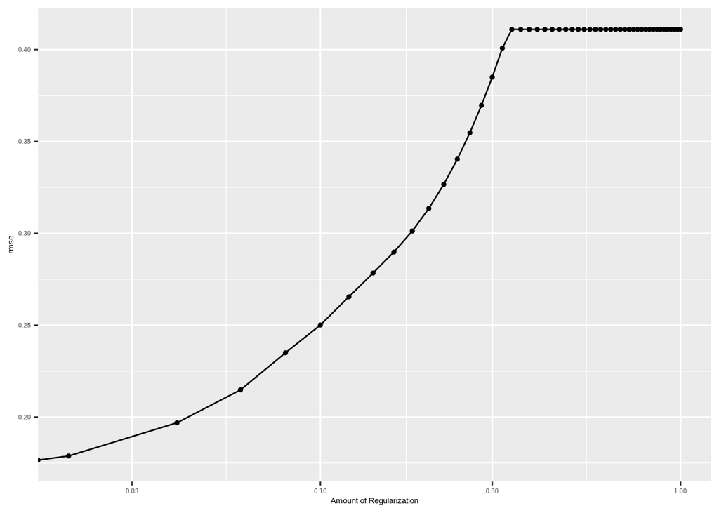

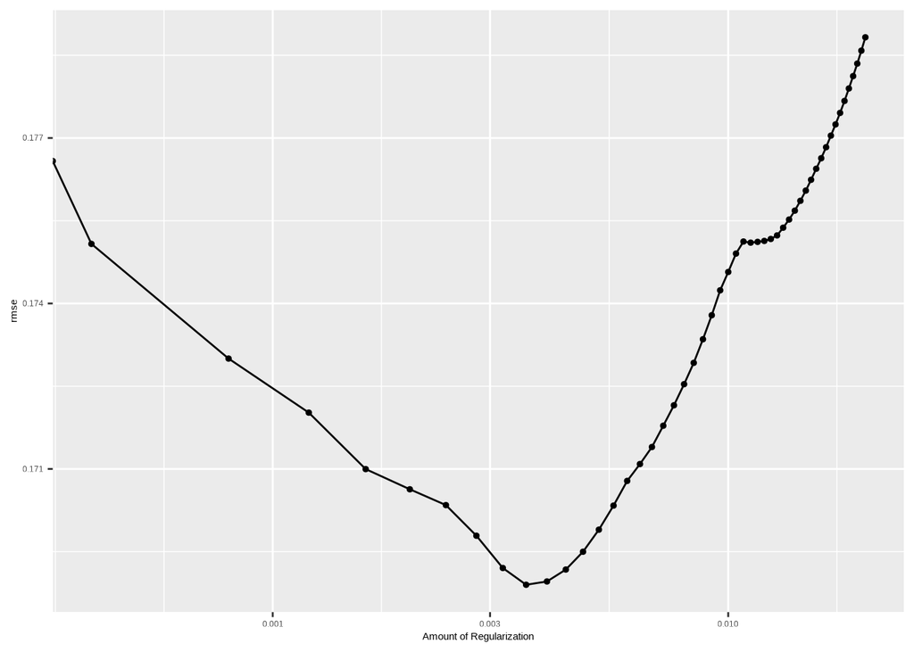

```r
set.seed(9753)
Boston_cv <- training(bostonPart) |> vfold_cv(v=10)

LASSO_grid <- grid_regular(penalty(range = c(0, 1), trans = NULL),
                          levels = 51)

set.seed(1)
lasso1_flujo_tuned <- flujoLASSO1 |>
                        tune_grid(
                          resamples = Boston_cv,
                          metrics   = metric_set(rmse),
                          grid      = LASSO_grid
                          )
lasso1_flujo_tuned |> autoplot()

####
LASSO_grid <- grid_regular(penalty(range = c(0, 0.02), trans = NULL),
                          levels = 51)

set.seed(1)
lasso1_flujo_tuned <- flujoLASSO1 |>
                        tune_grid(
                          resamples = Boston_cv,
                          metrics   = metric_set(rmse),
                          grid      = LASSO_grid
                          )

lasso1_flujo_tuned |> autoplot()
```

```r
lasso1_flujo_tuned |> show_best(metric = "rmse") |>
  kbl(digits = 4, caption = "Tabla 11. Mejores lambdas en el Modelo 1 de LASSO") |> kable_paper("hover")
```

Tabla 11. Mejores lambdas en el Modelo 1 de LASSO

| penalty | .metric | .estimator | mean | n | std_err | .config |
| --- | --- | --- | --- | --- | --- | --- |
| 0.0036 | rmse | standard | 0.1689 | 10 | 0.0123 | pre0_mod10_post0 |
| 0.0040 | rmse | standard | 0.1690 | 10 | 0.0119 | pre0_mod11_post0 |
| 0.0044 | rmse | standard | 0.1692 | 10 | 0.0116 | pre0_mod12_post0 |
| 0.0032 | rmse | standard | 0.1692 | 10 | 0.0129 | pre0_mod09_post0 |
| 0.0048 | rmse | standard | 0.1695 | 10 | 0.0114 | pre0_mod13_post0 |

```r
# lambda1 <- 0 #
lambda1 <- lasso1_flujo_tuned |> select_best(metric = "rmse")
```

Notad que muestro dos búsquedas de valores, refinando en la segunda la zona que aparecía como más probable en la primera. En general, se deberían probar varios rangos para el hiper-parámetro buscando una forma de U para el valor con mínimo error; se puede empezar con rangos amplios y luego buscar valores en un rango más fino, entorno al valor donde se ve el mínimo. NO está claro que queráis mostrarlos todos o incluso que queráis mostrar más de uno.

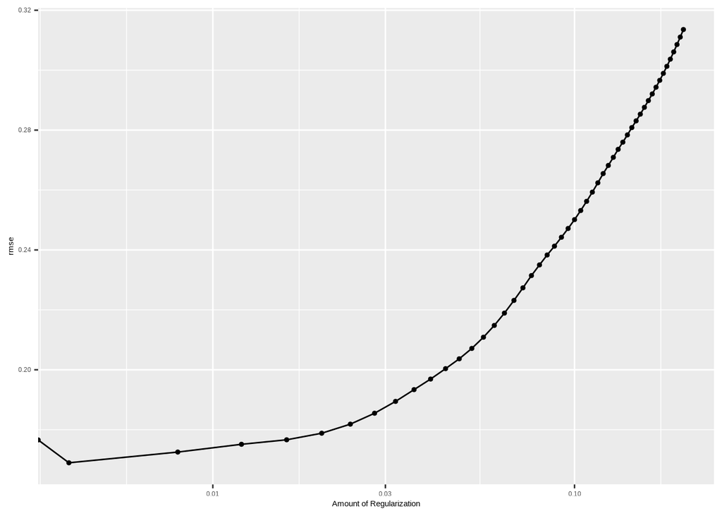

Figura 12. Ajuste de lamdba, modelo 2

```r
LASSO_grid <- grid_regular(penalty(range = c(0, 0.2), trans = NULL),
                          levels = 51)

set.seed(1)
lasso2_flujo_tuned <- flujoLASSO2 |>
                        tune_grid(
                          resamples = Boston_cv,
                          metrics   = metric_set(rmse),
                          grid      = LASSO_grid
                          )

lasso2_flujo_tuned |> autoplot()
```

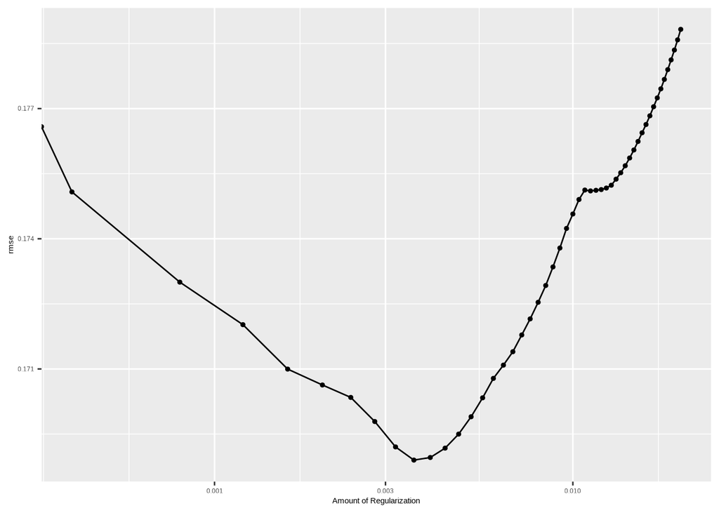

Figura 12. Ajuste de lamdba, modelo 2

```r
####
LASSO_grid <- grid_regular(penalty(range = c(0, 0.02), trans = NULL),
                          levels = 51)

set.seed(1)
lasso2_flujo_tuned <- flujoLASSO2 |>
                        tune_grid(
                          resamples = Boston_cv,
                          metrics   = metric_set(rmse),
                          grid      = LASSO_grid
                          )

lasso2_flujo_tuned |> autoplot()
```

```r
lasso2_flujo_tuned  |> show_best(metric = "rmse") |>
  kbl(digits = 4, caption = "Tabla 12. Mejores lambdas en el Modelo 2 de LASSO") |> kable_paper("hover")
```

Tabla 12. Mejores lambdas en el Modelo 2 de LASSO

| penalty | .metric | .estimator | mean | n | std_err | .config |
| --- | --- | --- | --- | --- | --- | --- |
| 0.0036 | rmse | standard | 0.1689 | 10 | 0.0123 | pre0_mod10_post0 |
| 0.0040 | rmse | standard | 0.1690 | 10 | 0.0119 | pre0_mod11_post0 |
| 0.0044 | rmse | standard | 0.1692 | 10 | 0.0116 | pre0_mod12_post0 |
| 0.0032 | rmse | standard | 0.1692 | 10 | 0.0129 | pre0_mod09_post0 |
| 0.0048 | rmse | standard | 0.1695 | 10 | 0.0114 | pre0_mod13_post0 |

```r
# lambda2 <- 0
lambda2 <- lasso2_flujo_tuned |> select_best(metric = "rmse")
```

Vamos a finalizar los modelos y ver sus métricas en la muestra de prueba.

```r
LASSO_final <- list()
LASSO_final[[1]] <- flujoLASSO1 |>
                    finalize_workflow(lambda1) |>
                    last_fit(bostonPart)  |>
                    collect_metrics()

LASSO_final[[2]] <- flujoLASSO2 |>
                    finalize_workflow(lambda2) |>
                    last_fit(bostonPart)  |>
                    collect_metrics()

LASSO_final |> bind_rows(.id = "modelo") |>
  pivot_wider(names_from = .metric, values_from=.estimate) |>
  select(-.estimator) |>
  kbl(digits = 4, caption = "Tabla 13. Métricas de LASSO") |> kable_paper("hover")
```

Tabla 13. Métricas de LASSO

| modelo | .config | rmse | rsq |
| --- | --- | --- | --- |
| 1 | pre0_mod0_post0 | 0.2411 | 0.67 |
| 2 | pre0_mod0_post0 | 0.2411 | 0.67 |

En este caso, ambos modelos tienen un comportamiento predictivo muy similar. Esto puede deberse a que ambos son muy similares, salvo por usar polinomios en lugar de discretizaciones. No es raro que ambos tengan un comportamiento predictivo similar, puesto que ambas formas aproximan (aunque de forma ligeramente distinta) relaciones no lineales.

## kNN

Consideremos modelos de k vecinos. Este método es suficientemente flexible para considerar posibles no linealidades en todas las variables. Vamos a ajustar el número de vecinos por validación cruzada con el precio y su logaritmo como variables dependientes. Podríamos considerar otras variantes como usar el absoluto para la distancia o usar más o menos variables explicativas en el modelo; también usar discretizaciones de variables continuas (aunque esto no es muy habitual ni útil en kNN).

NOTA: como vemos aquí, conviene empezar con un rango amplio de valores para el hiperparámetro, sin probar cada valor del rango (ej., entre 1 y 21 aumentando valores de 2 en 2), y luego refinar en la zona donde parece estar el mínimo.

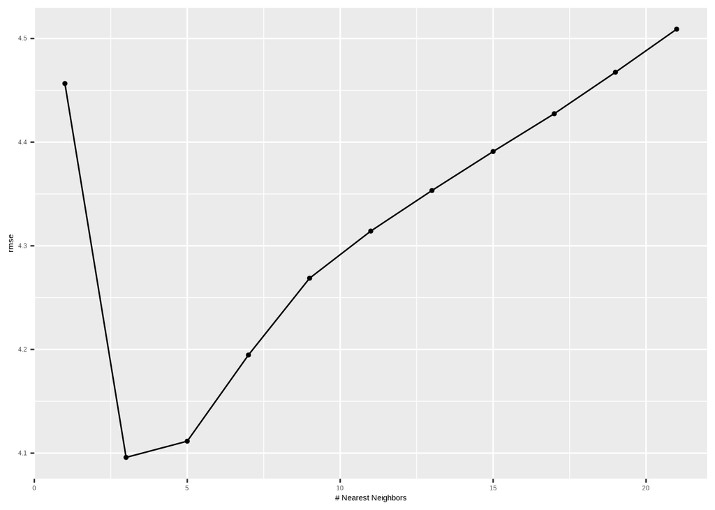

Figura 13. Ajuste de k vecinos, modelo 1

```r
knn1_receta <- training(bostonPart) |>
  recipe(medv ~ chas + crim + zn + indus + nox + rm +
           age + dis + rad + tax + ptratio + b + lstat) |>
  step_normalize(all_predictors(), -all_nominal()) |>
  step_dummy(all_nominal_predictors())

knn1_modelo <- nearest_neighbor(mode = "regression",
                  neighbors = tune(), dist_power = 2) |>
                set_engine("kknn")

knn1_flujo <- workflow() |>
  add_recipe(knn1_receta) |>
  add_model(knn1_modelo)

knn_grid <- grid_regular(neighbors(range = c(1, 21), trans = NULL),
                          levels = 11)

set.seed(1)
knn1_flujo_tuned <- knn1_flujo |>
                        tune_grid(
                          resamples = Boston_cv,
                          metrics   = metric_set(rmse),
                          grid      = knn_grid
                          )

knn1_flujo_tuned  |> autoplot()
```

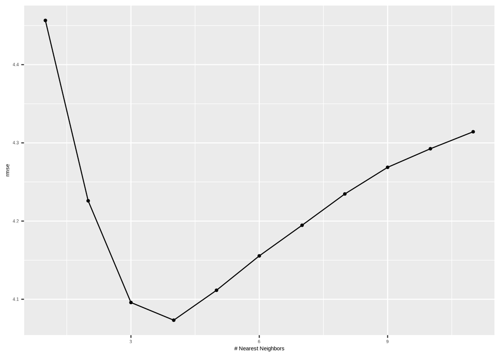

Figura 13. Ajuste de k vecinos, modelo 1

```r
knn_grid <- grid_regular(neighbors(range = c(1, 11), trans = NULL),
                          levels = 11)
###########
set.seed(1)
knn1_flujo_tuned <- knn1_flujo |>
                        tune_grid(
                          resamples = Boston_cv,
                          metrics   = metric_set(rmse),
                          grid      = knn_grid
                          )

knn1_flujo_tuned  |> autoplot()
```

```r
knn1_flujo_tuned  |> show_best(metric = "rmse") |>
  kbl(digits = 4, caption = "Tabla 14. k-vecinos óptimo en el Modelo 1") |> kable_paper("hover")
```

Tabla 14. k-vecinos óptimo en el Modelo 1

| neighbors | .metric | .estimator | mean | n | std_err | .config |
| --- | --- | --- | --- | --- | --- | --- |
| 4 | rmse | standard | 4.0733 | 10 | 0.3965 | pre0_mod04_post0 |
| 3 | rmse | standard | 4.0959 | 10 | 0.4083 | pre0_mod03_post0 |
| 5 | rmse | standard | 4.1115 | 10 | 0.3893 | pre0_mod05_post0 |
| 6 | rmse | standard | 4.1555 | 10 | 0.3876 | pre0_mod06_post0 |
| 7 | rmse | standard | 4.1946 | 10 | 0.3897 | pre0_mod07_post0 |

```r
k1 <- knn1_flujo_tuned |> select_best(metric = "rmse")
```

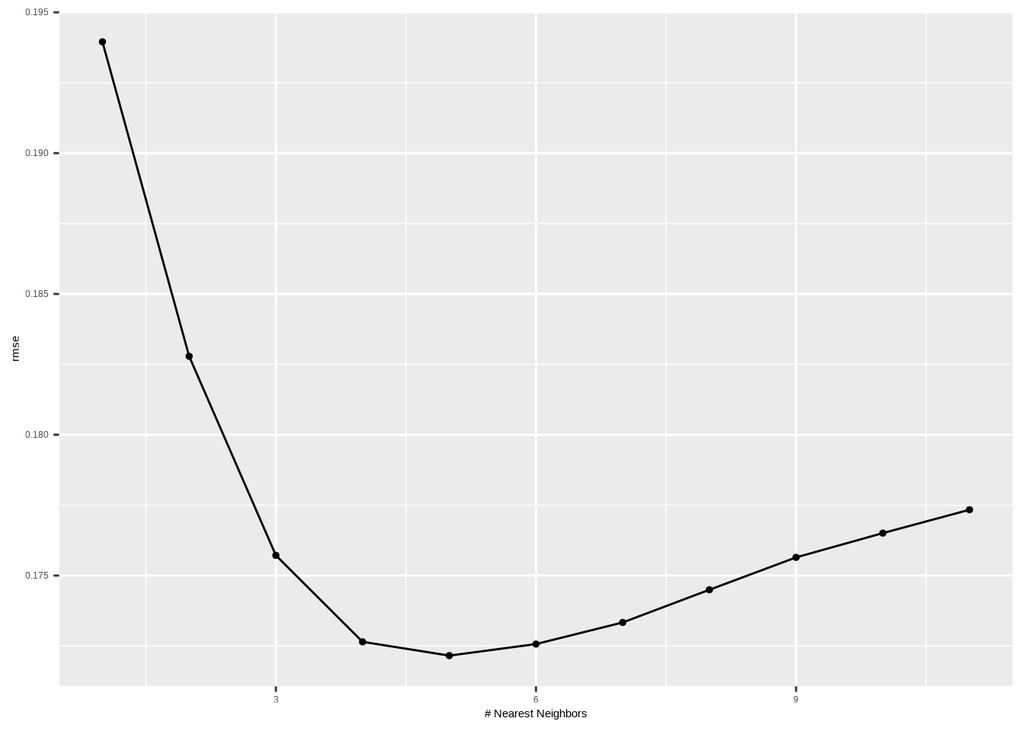

Figura 14. Ajuste de k vecinos, modelo 2

```r
knn2_receta <- training(bostonPart) |>
  recipe(lmedv ~ chas + crim + zn + indus + nox + rm +
           age + dis + rad + tax + ptratio + b + lstat) |>
  step_normalize(all_predictors(), -all_nominal()) |>
  step_dummy(all_nominal_predictors())

knn2_flujo <- workflow() |>
  add_recipe(knn2_receta) |>
  add_model(knn1_modelo)

knn_grid <- grid_regular(neighbors(range = c(1, 11), trans = NULL),
                          levels = 11)

set.seed(1)
knn2_flujo_tuned <- knn2_flujo |>
                        tune_grid(
                          resamples = Boston_cv,
                          metrics   = metric_set(rmse),
                          grid      = knn_grid
                          )

knn2_flujo_tuned  |> autoplot()
```

```r
knn2_flujo_tuned  |> show_best(metric = "rmse") |>
  kbl(digits = 4, caption = "Tabla 15. k-vecinos óptimo en el Modelo 2") |> kable_paper("hover")
```

Tabla 15. k-vecinos óptimo en el Modelo 2

| neighbors | .metric | .estimator | mean | n | std_err | .config |
| --- | --- | --- | --- | --- | --- | --- |
| 5 | rmse | standard | 0.1722 | 10 | 0.0099 | pre0_mod05_post0 |
| 6 | rmse | standard | 0.1726 | 10 | 0.0104 | pre0_mod06_post0 |
| 4 | rmse | standard | 0.1726 | 10 | 0.0096 | pre0_mod04_post0 |
| 7 | rmse | standard | 0.1733 | 10 | 0.0107 | pre0_mod07_post0 |
| 8 | rmse | standard | 0.1745 | 10 | 0.0110 | pre0_mod08_post0 |

```r
k2 <- knn2_flujo_tuned |> select_best(metric = "rmse")
```

El número óptimo de vecinos es

| neighbors | .config |
| --- | --- |
| 4 | pre0_mod04_post0 |

| neighbors | .config |
| --- | --- |
| 5 | pre0_mod05_post0 |

```r
knn_final <- list()
knn_final[[1]] <- knn1_flujo |>
                    finalize_workflow(k1) |>
                    last_fit(bostonPart)  |>
                    collect_metrics()

knn_final[[2]] <- knn2_flujo |>
                    finalize_workflow(k2) |>
                    last_fit(bostonPart)  |>
                    collect_metrics()

knn_final |> bind_rows(.id = "modelo") |>
  pivot_wider(names_from = .metric, values_from=.estimate) |>
  select(-.estimator) |>
  kbl(digits = 4, caption = "Tabla 16. Métricas de kNN") |> kable_paper("hover")
```

Tabla 16. Métricas de kNN

| modelo | .config | rmse | rsq |
| --- | --- | --- | --- |
| 1 | pre0_mod0_post0 | 4.2681 | 0.7289 |
| 2 | pre0_mod0_post0 | 0.2031 | 0.7350 |

Comparando estos resultados con los de la Tabla para LASSO, queda claro que kNN tiene una mejor capacidad predictiva, tanto para la variable de precio como usando el logaritmo del precio. Sin embargo, estos modelos no nos dicen mucho sobre qué factores afectan a esa predicción (no tenemos ni modelo paramétrico y contrastes, ni representación gráficas o medidas de importancia).

## Árboles de regresión

Pasamos a considerar modelos de árboles de decisión. Notad que para ajustar el coste de complejidad puede ser necesario varios rangos. Dado que hemos visto que sistemáticamente el modelo con el logaritmo del precio predice mejor, nos centramos en ese modelo (aunque esto es obviamene una elección y quizás deberían probarse más).

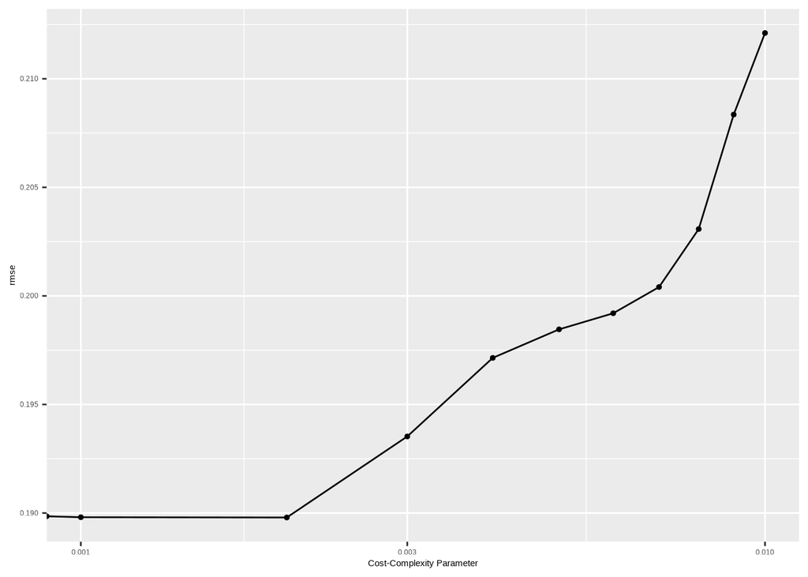

Figura 15. Ajuste de árboles, modelo 2

```r
arbol2_receta <- training(bostonPart) |>
  recipe(lmedv ~ chas + crim + zn + indus + nox + rm +
           age + dis + rad + tax + ptratio + b + lstat)

arbol2_modelo <-  decision_tree(mode = "regression",
                                     cost_complexity = tune()) |>
                          set_engine("rpart")

arbol2_flujo <- workflow() |>
  add_recipe(arbol2_receta) |>
  add_model(arbol2_modelo)

arbol_grid <- grid_regular(cost_complexity(range = c(0, 0.01), trans = NULL),
                          levels = 11)
set.seed(1)
arbol2_flujo_tuned <- arbol2_flujo |>
                        tune_grid(
                          resamples = Boston_cv,
                          metrics   = metric_set(rmse),
                          grid      = arbol_grid
                          )

arbol2_flujo_tuned  |> autoplot()
```

```r
arbol2_flujo_tuned  |> show_best(metric = "rmse") |>
  kbl(digits = 4, caption = "Tabla 17. Coste de complejidad  en el Modelo 1") |> kable_paper("hover")
```

Tabla 17. Coste de complejidad en el Modelo 1

| cost_complexity | .metric | .estimator | mean | n | std_err | .config |
| --- | --- | --- | --- | --- | --- | --- |
| 0.002 | rmse | standard | 0.1898 | 10 | 0.0119 | pre0_mod03_post0 |
| 0.001 | rmse | standard | 0.1898 | 10 | 0.0122 | pre0_mod02_post0 |
| 0.000 | rmse | standard | 0.1899 | 10 | 0.0123 | pre0_mod01_post0 |
| 0.003 | rmse | standard | 0.1935 | 10 | 0.0123 | pre0_mod04_post0 |
| 0.004 | rmse | standard | 0.1971 | 10 | 0.0117 | pre0_mod05_post0 |

```r
cost2 <- arbol2_flujo_tuned |> select_best(metric = "rmse")
```

```r
arbol_final <- arbol2_flujo |>
                    finalize_workflow(cost2) |>
                    last_fit(bostonPart)

arbol_final |>  collect_metrics() |>
  pivot_wider(names_from = .metric, values_from=.estimate) |>
  select(-.estimator) |>
  kbl(digits = 4, caption = "Tabla 18. Métricas del árbol") |> kable_paper("hover")
```

Tabla 18. Métricas del árbol

| .config | rmse | rsq |
| --- | --- | --- |
| pre0_mod0_post0 | 0.2064 | 0.7394 |

Vemos que el mejor árbol de regresión es mejor que LASSO y similar a kNN (en logaritmos). Además podemos ver el flujo del árbol para hacernos una idea de qué factores están afectando a la predicción

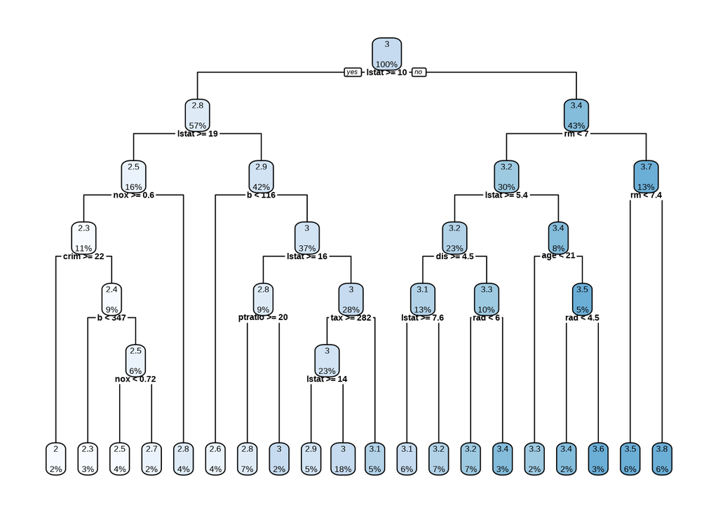

Figura 16a. Mejor árbol de regresión, modelo 2

```r
arb <- arbol_final$.workflow[[1]] |>
  extract_fit_parsnip()

rpart.plot(arb$fit)
```

También podemos recurrir a medidas de importancia de las variables.

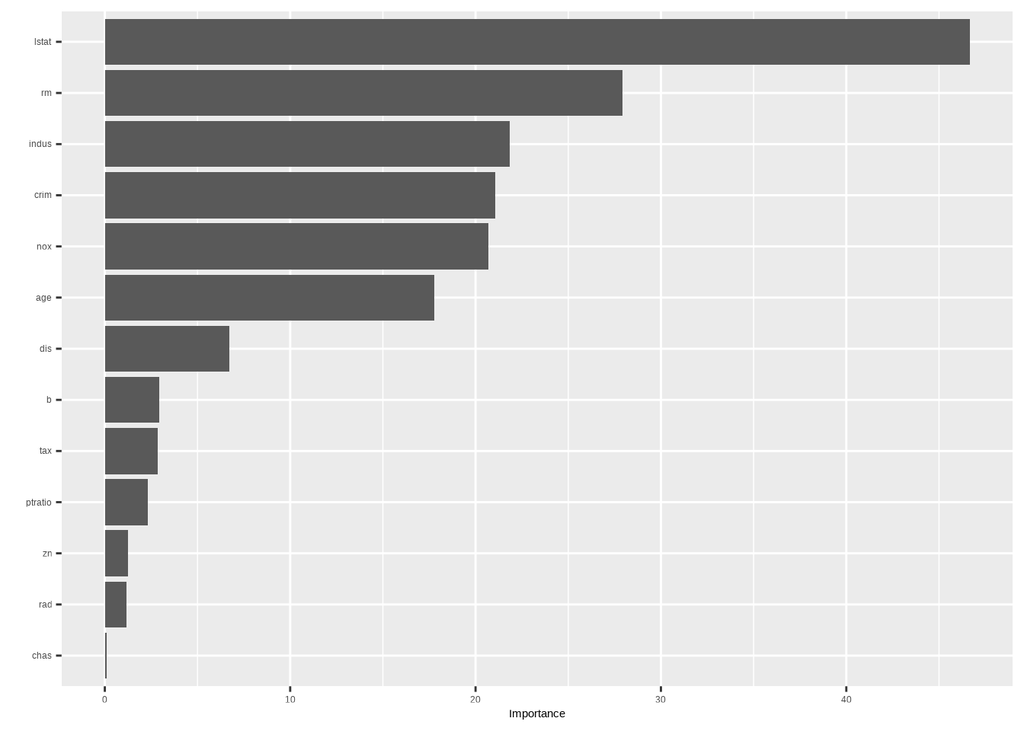

Figura 16b. Importancia en el mejor árbol de regresión, modelo 2

```r
arbol_final$.workflow[[1]] |>
  extract_fit_parsnip() |>
  vip(num_features = 14)
```

Estos resultado son interesantes, más allá de su capacidad predictiva, porque son informativos son las interacciones entre distintas características. Como sabemos y podemos ver, los árboles trabajan discretizando las variables continuas discretizadas. Pero además implican distintas interacciones entre rangos de las variables para el resultado final. Por ejemplo, vemos que en los niveles superiores del árbol tenemos distintos niveles de población desfavorecida en el barrio, `lstat`; de hecho, vemos también (como era esperable) que es la variable con mayor valor de la importancia. Pero según los distintos valores de `lstat` importan diferentes características: cuando `lstat` es bajo ($<10$) el precio viene determinado por el número de habitaciones de la vivienda, mientras que cuando es alto por la cantidad de contaminación o la proporición de gente de color en el vecindario.

## Random Forests

Intentamos ver si un modelo de “random forests” puede mejorar al árbol de regresión u otros modelos.

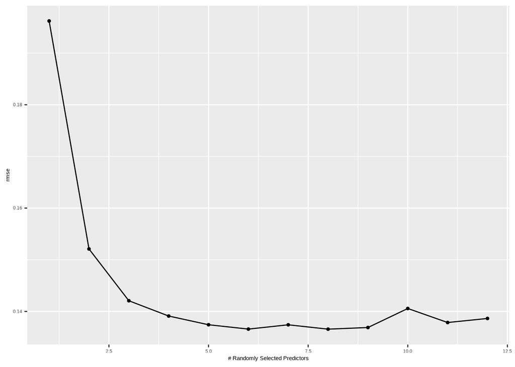

Figura 17. Ajuste de RF, modelo 2

```r
rf2_receta <- arbol2_receta

rf2_modelo <-  rand_forest(mode = "regression",
                                       mtry = tune(), trees = 100) |>
                          set_engine("ranger", importance = "impurity")

rf2_flujo <- workflow() |>
  add_recipe(rf2_receta) |>
  add_model(rf2_modelo)

rf_grid <- grid_regular(mtry(range = c(1, 12), trans = NULL),
                          levels = 12)

rf2_flujo_tuned <- rf2_flujo |>
                        tune_grid(
                          resamples = Boston_cv,
                          metrics   = metric_set(rmse),
                          grid      = rf_grid
                          )

rf2_flujo_tuned |> autoplot()
```

```r
rf2_flujo_tuned  |> show_best(metric = "rmse") |>
  kbl(digits = 4, caption = "Tabla 19. Ajuste de Random Forest  en el Modelo 2") |> kable_paper("hover")
```

Tabla 19. Ajuste de Random Forest en el Modelo 2

| mtry | .metric | .estimator | mean | n | std_err | .config |
| --- | --- | --- | --- | --- | --- | --- |
| 8 | rmse | standard | 0.1366 | 10 | 0.0095 | pre0_mod08_post0 |
| 6 | rmse | standard | 0.1366 | 10 | 0.0087 | pre0_mod06_post0 |
| 9 | rmse | standard | 0.1369 | 10 | 0.0090 | pre0_mod09_post0 |
| 7 | rmse | standard | 0.1374 | 10 | 0.0088 | pre0_mod07_post0 |
| 5 | rmse | standard | 0.1374 | 10 | 0.0092 | pre0_mod05_post0 |

```r
mtry2 <- rf2_flujo_tuned |> select_best(metric = "rmse")
```

El número óptimo de variables a usar (aleatoriamente) en cada nodo son

| mtry | .config |
| --- | --- |
| 8 | pre0_mod08_post0 |

Por último finalizamos el modelo

```r
rf_final <- rf2_flujo |>
                    finalize_workflow(mtry2) |>
                    last_fit(bostonPart)

rf_final |>  collect_metrics() |>
  pivot_wider(names_from = .metric, values_from=.estimate) |>
  select(-.estimator) |>
  kbl(digits = 4, caption = "Tabla 20. Métricas de RF") |> kable_paper("hover")
```

Tabla 20. Métricas de RF

| .config | rmse | rsq |
| --- | --- | --- |
| pre0_mod0_post0 | 0.1627 | 0.8225 |

El modelo de “Random Forest” incluso mejora claramente a “kNN”. En este caso, podemos ver qué variables han resultados mejores predictores del precio.

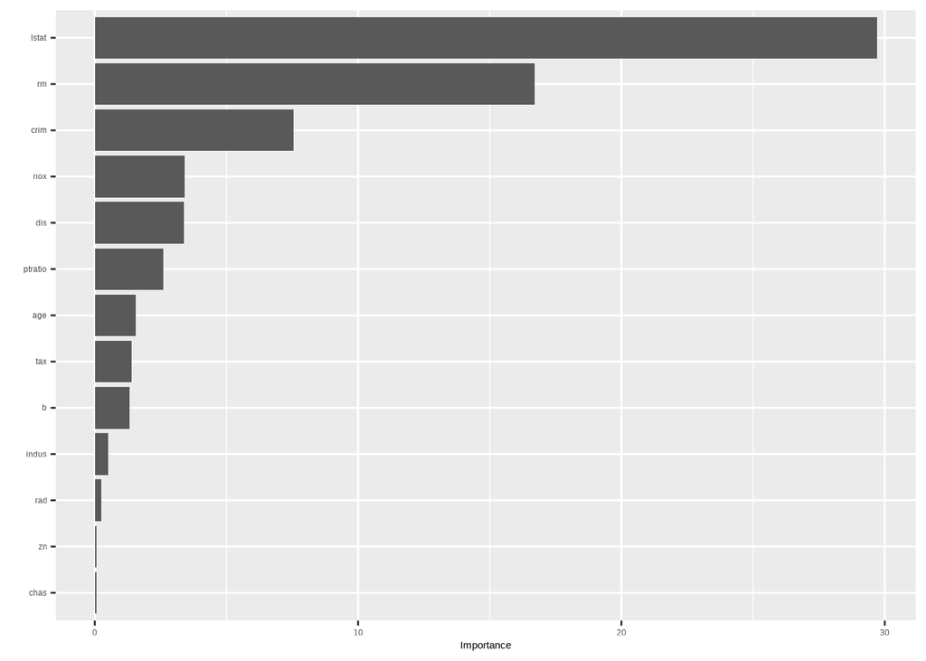

Figura 18. Importancia en el mejor RF, modelo 2

```r
rf_final$.workflow[[1]] |>
  extract_fit_parsnip() |>
  vip(num_features = 14)
```

Este gráfico nos indica que la variable más importante (con diferencia) es la relacionada con la “pobreza” de la zona en la que se encuentra la casa. Después nos encontramos una característica de la casa en sí (número de habitaciones, aunque realmente es la media de la zona) y la criminalidad de la zona. No existe un criterio formal para decidir en que punto parar determinar qué variables son importantes. Quizás en este caso se puede “argumentar” que hay una caída mayor de la importancia después de la contaminación de la zona, la calidad de las escuelas y la distancia al centro.

# Conclusión

Uno de los objetivos de este informe era determinar los atributos del vecindario que mejor explicaban (no necesariamente causan) la variación en los precios de las viviendas. Los mejores modelos son regresión lineal, que incorpora relaciones no lineales, y “random forest” que también establece una relación altamente no lineal entre el precio y los factores observados. También ofrecen herramientas para interpretar los resultados. Ambos modelos coinciden en la importancia de que el barrio esté en una zona “deprimida” (mucho porcentaje de población con bajo estatus social) en la determinación del precio. Con mayor o menor importancia, también coinciden en la relevancia de la criminalidad en la zona, el número medio de habitaciones y el ratio de alumnos por profesor. Algunas características como la edad o una localización cercana al río no parecen ser importantes; esto es una diferencia respecto al análisis de covariación, donde sí se apreciaba cierta correlación. Esto nos indica que esas características están relacionadas con otras que sí son más relevantes en la fijación de precios. Los resultados del modelo de árboles también son relevantes para aprender sobre las interacciones entre características para determinar el precio de las casas. Debéis usar estos resultados para reestimar modelos más interpretables (como regresión lineal o árboles) para hacer comentarios específicos sobre el impacto de cambios **concretos** de variables particularmente relevantes sobre el precio de las casas. PENSAD en qué cuestiones pueden ser interesantes si estáis trabajando en una inmobiliaria o en una empresa de tasación de viviendas, en este caso, o en una empresa del sector apropiado para los datos que elijáis.

Por otro lado estos resultados también se podrían utilizar para predecir el precio de una nueva casa (o saber si una en el mercado está sobrevalorada).

```r
rf_final$.workflow[[1]] |>
  predict(new_data = tibble(chas = "Yes", crim = 0.03,  zn = 0,
                            indus = 7, nox = 0.5, rm = 2,
                            age = 10,  dis = 6, rad = 5,
                            tax = 290, ptratio = 20, b = 390, lstat=9)) |>
  exp()
```

| .pred |
| --- |
| 20.76656 |

Notad que debemos deshacer el logaritmo para dar una predicción en unas unidades con sentido (miles de dólares). Recordad que también podemos ofrecer un intervalo de confianza para la predicción.

Fijaos que en otros contextos o con otros datos podéis tener un caso más obvio que predecir (o no). Y podéis usar intervalos de confianza en lugar de predicción puntual para determinar si una casa está sobrevalorada o infravalorada. En cualquier caso, debéis elegir y *justificar* los valores elegidos para predecir: en este caso, una casa observada en los datos con particular interés, una casa común en la zona. En el proyecto que elijáis, también deben existir razones para que ese caso sea relevante para predecir.

Recordad que también podemos estar interesados en usar el modelo para interpetar el efecto de alguna o algunas variables. Nuevamente, tendréis que justificar por qué esas variables son interesantes y cómo se interpretan los resultados. Como hemos visto, podemos considerar la información que LASSO y/o “Random Forest” nos dan sobre las variables para estimar modelos más interpretables y extraer conclusiones.

# Apéndice A

Como se ha comentado, nuestro conjunto de datos dispone de 506 observaciones y 14 variables. A continuación se presenta una breve descripción de cada variable:

| Variable | Descripción |
| --- | --- |
| CRIM | tasa de criminalidad per cápita por ciudad |
| ZN | proporción de terreno residencial dividido en |
|  | zonas para lotes de más de 25,000 pies cuadrados. |
| INDUS | proporción de acres de negocios no comerciales por zona |
| CHAS | variable “dummy”del río Charles |
|  | (1 si la zona limita con el río; si no, 0) |
| NOX | concentración de óxidos nítricos (partes por 10 millones) |
| RM | número medio de habitaciones por vivienda |
| AGE | proporción de casas ocupadas por sus propietarios |
|  | construidas antes de 1940. |
| DIS | distancia media ponderada a cinco centros de empleo de Boston |
| RAD | índice de accesibilidad a carreteras radiales |
| TAX | impuesto sobre el valor total de la propiedad |
|  | (por cada $10,000) |
| PTRATIO | número de alumnos por docente en los colegios de la zona (“town”) |
| B | 1000(Bk - 0.63)^2 donde Bk es la proporción de población de color |
|  | en la zona (0.63 es la media en la ciudad) |
| LSTAT | porcentaje de población desfavorecida (bajo estatus social) |
| MEDV | valor mediano de las viviendas ocupadas por sus propietarios |
|  | (en miles de dólares) |

## Notas

[^1]: Todo esta discusión sobre modelos de regresión lineal aplica a regresión logística para problemas de clasificación.